# Final Project 2016: Development Builds Resilience

# Authors: Elizabeth Cheever, Erin Comerford, Sarah McGough

# Overview and Motivation

National governments and global leaders are rallying behind a common goal to end global hunger and poverty by 2030, perhaps best embodied by the UN’s 17 Sustainable Development Goals (SDGs), the most comprehensive effort yet to tackle the toughest development challenges facing the global community. Bread for the World supports the analysis of leaders like the World Bank and the World Food Program, which insists that getting extreme hunger and malnutrition to the ‘zero zone’ by 2030 is achievable in most countries. Yet there remains a small group of fragile states where unique vulnerabilities make ending hunger much more difficult. Those vulnerabilities can be categorized into three groups, known here as the “three Cs”: conflict, corruption, and climate change. Countries vary in their level of vulnerability on each of the 3 Cs. Some may only be vulnerable in only one or two areas, while others could be vulnerable in all three. A rating index already exists for measuring country vulnerability on each of the three Cs.

# Related Work

As students at the Harvard T.H. Chan School of Public Health, we are passionate about improving health outcomes for the global population. Thus the idea of producing work that could help achieve the Millennium Development Goal to “end hunger, achieve food security and improved nutrition and promote sustainable agriculture” inspired us. Additional conversations with Derek Schwabe, a research associate at Bread for the World Institute, added to our enthusiasm for this topic.

Additional reading we did included the following websites :

Bread For The World: http://www.bread.org/

Millennium Development Goals: http://www.un.org/millenniumgoals/

As well as the articles http://www.bread.org/blog/hunger-fragile-states-where-start and https://www.wider.unu.edu/publication/vulnerability-hunger and http://www.worldvision.org/news-stories-videos/what-are-fragile-states.

# Initial Goals

Using data on hunger and hunger predictors such as GDP in addition to data on climate, corruption, and conflict we wanted to achieve the following goals:

1. Create a dataset that combines measures on the 3Cs as well as on hunger that is in a useable format for organizations such as Bread for the World
2. Create a single metric that quantifies and summarizes the three Cs per country
3. Assess the relationship between hunger predictors, such as the Human Development Index, and the three Cs at the country- and continent-level
4. Determine which of the 3Cs are most predictive of hunger

# Building a Dataset

Our analysis is comprised of the following datasets:

1. **HARMONIZED_LIST_OF_FRAGILE_SITUATIONS_FY15.csv** which is the 2014 World Bank list of countries that are deemed fragile states (low-income countries with particularly weak policies, institutions, and governance). You can read more about how this list is created here: http://pubdocs.worldbank.org/pubdocs/publicdoc/2015/7/586581437416356109/FCS
2. **gain.csv** which is the ND-GAIN Country Index, which summarizes a country’s vulnerability to climate change and other global challenges in combination with its readiness to improve resilience. All scores are between 0 and 100. A higher score means a country has more capacity to deal with potential climate risk. More information can be found here: http://index.gain.org/ranking

We also include the **gain_delta.csv** dataset which is the GDP adjusted ND-GAIN scores. Again, more details can be found here: http://index.gain.org/ranking

3. **GlobalHungerIndexScore.csv** which are the 2015 Global Hunger Index Scores. These scores are meant to measure and track hunger globally, regionally, and by country. The scores are measured on a 100-point scale where 0 is the best score (no hunger) and 100 the worst. You can read more about this dataset here: https://dataverse.harvard.edu/dataset.xhtml?persistentId=doi:10.7910/DVN/JL16EW
4. **2015_CPI_data.csv** which is the 2015 Corruption Perceptions Index. A country or territory’s score indicates the perceived level of public sector corruption on a scale of 0 (highly corrupt) to 100 (very clean). More information can be found here: http://www.transparency.org/cpi2015#results-table
5. **LowIncomeFoodDeficitCountries.csv** which is the list of the 2015 Low-Income Food-Deficit Countries. An explanation of how this list is created can be found here:http://www.fao.org/countryprofiles/lifdc/en/

```r
library(readr)
library(ggplot2)
library(tidyr)
library(sjmisc)
library(dplyr)
library(plyr)
library(knitr)
library(stringr)
library(countrycode)
#####################################################################
############################ IMPORT DATA ############################
#####################################################################
#This is World Bank list of data on fragile - 2014
harmonized_list<-read_csv('HARMONIZED_LIST_OF_FRAGILE_SITUATIONS_FY15.csv')
#Clean rows
harmonized_list<-harmonized_list[(seq(2,to=nrow(harmonized_list),by=2)),]
harmonized_list<-harmonized_list[-nrow(harmonized_list),]

# The ND-GAIN Country Index summarizes a country's vulnerability to climate change and
nd_scores <- read_csv('gain.csv')
#GDP adjusted ND-GAIN scores.
nd_adjusted_scores <- read_csv('gain_delta.csv')

#2015 Global Hunger Index Scores
global_hunger_index<-read_csv('GlobalHungerIndexScore.csv')

#CORRUPTION PERCEPTIONS INDEX 2015 (CPI)
corruption_index<-read_csv('2015_CPI_data.csv')

#Low-Income Food-Deficit Countries  2015
LIFDC<-read_csv('LowIncomeFoodDeficitCountries.csv')
```

We then subset the data to the most recent year available as we believe that this is most important and relevant data when thinking forward to achieving the ‘zero zone’ by 2030.

```r
#Subset vulnerability to climate change to 2014
nd_adj_2014 <- nd_adjusted_scores %>% select(ISO3,`2014`)
#Subset hunger scale 2015
global_hunger_index_2015 <- global_hunger_index %>% select(Country,`2015`)
#Corruption_index is already just for 2015
corruption_index_subset<- corruption_index %>% select(CPI2015,wbcode)
```

Now we aggregate all the data into one dataframe. We used the “countrycode” package for a list of all country names and codes. This R package has data on 273 countries.

```r
#NOTE: The following will be indicators: fragile states (harmonized_list), Low-Income Food-Deficit Countries (LIFCD)
#NOTE: The following are on a scale:  vulnerability to climate change (nd_adjusted_scores, n=192), hunger scale (global_hunger_index, n=131)
# corruption perception index (corruption_index, n=168)

#Get all country names, codes, regions from package countrycode (data on 273 countries)
df <- countrycode_data %>% select(country.name,continent,region,iso3c,wb) %>%
  dplyr::rename(Country = country.name,ISO3=iso3c,wbcode=wb)

#Decided we wanted to use non-GDP-adjusted ND gain scores so now we join them in
climate <- nd_scores %>% select(ISO3, 22)
df <- left_join(df, climate, by="ISO3") %>% dplyr::rename(Climate_NominalScore=`2014`)

#Merge in vulnerability to climate change (nd_adjusted_scores, n=192 but only 180 with 2014 score); checked and merge is perfect
df <- df %>% left_join(nd_adj_2014,by='ISO3') %>% dplyr::rename(Climate_AdjustedScore=`2014`)

#Merge in hunger scale (global_hunger_index_2015, n=131, only 117 have 2015 data) - had to modify some country names to match in the .csv file
df <- df %>% left_join(global_hunger_index_2015 ,by='Country') %>% dplyr::rename(Hunger_Score=`2015`)

#Merge in corruption perception index (corruption_index, n=168, all have 2015 data) - had to modify some wb codes to match in the .csv file
df <- df %>% left_join(corruption_index_subset ,by='wbcode') %>% dplyr::rename(Corruption_Score=CPI2015)
#We add in South Sudan as a country in this merge so we need to update the name correctly
df[229, 'Country'] = 'South Sudan'

#Merge in fragile states (harmonized_list) of 33 countries; Indicator=1 if it is a fragile state
df$Fragile_State <- ifelse(df$Country %in% harmonized_list$Country, 1, 0)

#Merge in Low-Income Food-Deficit Countries (LIFCD) of 54 countries; indicator of if LIFCD or not
df$LIFDC <- ifelse(df$Country %in% LIFDC$Country, 1, 0)
```

Based on conversations with our TA (Joe) and Derek, we then decided to add other datasets to this dataframe as well. These datasets helped create a new predictor variable, conflict, as well as provide alternative outcomes that serve as proxies to hunger (GDP and the Human Development Index).

6. **Conflict.csv** which is the Global Conflict Risk Index (GCRI) developed by the European Union. We created a score that was the average of four primary risk sub-factors that were ranked on 0-10 scale: international conflict, national conflict, unemployment (as proxy for population disgruntlement), and repression. More information can be found at: http://conflictrisk.jrc.ec.europa.eu/
7. **GDP.csv** which is the gross domestic product (GDP) based on purchasing-power-parity (PPP) valuation of country. The units are Current international dollar (in billions). The data was obtained from the IMF website.
8. **HDI_table.csv** which is 2015 Human Development Index (HDI) data. It is a composite statistic of life expectancy, education, and income per capita indicators.

```r
#Read in the conflict data and create an average conflict score
conf <- read_csv("Conflict.csv")
conf <- conf %>% filter(YEAR==2014) %>% select(ISO, YEAR, COUNTRY, CON_INT, CON_NB, UNEMP, REPRESS)
conf$Average_Conflict <- (conf$CON_INT + conf$CON_NB + conf$UNEMP + conf$REPRESS)/4
names(conf)[1] <- "ISO3"
conf_sub <- conf %>% select(ISO3, Average_Conflict)
#Join the average conflict score to the data frame
df <- left_join(df, conf_sub, by="ISO3")  #df is now 274 by 12

# Add in GDP data
# Gross domestic product based on purchasing-power-parity (PPP) valuation of country GDP
# The units are Current international dollar (in billions)
gdp<- read_csv('GDP.csv')
gdp_subset<-gdp%>% select(Country,`2015`)
df <- df %>% left_join(gdp_subset,by="Country") %>% dplyr::rename(GDP=`2015`)
df$GDP<-as.numeric(df$GDP)

#Add in HDI data
hdi<- read_csv('HDI_table.csv')
df <- df %>% left_join(hdi,by="Country")
```

Then we created standardized values so that all scales were comparable since variables were measured on different scales.

```r
#Make z-scores (standardized and centered so everything is on the same scale)
df$Corruption_Zscore <- as.numeric(scale(df$Corruption_Score, center=TRUE, scale=TRUE))
df$Climate_Zscore <- as.numeric(scale(df$Climate_AdjustedScore, center=TRUE, scale=TRUE))
df$Conflict_Zscore <- as.numeric(scale(df$Average_Conflict, center=TRUE, scale=TRUE))
#Ensure all z-scores are in the correct format
df$Corruption_Zscore <- as.vector(df$Corruption_Zscore)
df$Climate_Zscore <- as.vector(df$Climate_Zscore)
df$Conflict_Zscore <- as.vector(df$Conflict_Zscore)
df$Hunger_Score <- as.numeric(df$Hunger_Score)
df$Hunger_Zscore <- as.numeric(scale(df$Hunger_Score, center=TRUE, scale=TRUE))
df$Climate_Nominal_Zscore <- as.numeric(scale(df$Climate_NominalScore, center=TRUE, scale=TRUE))
df$Conflict_Zscore_Reversed <- df$Conflict_Zscore*-1
```

Then we created summary scores based on the 3 Cs. We use z-scores to standardize all data on the 3 Cs so that they are comparable across different scales. Thus, the summary score is the average of these (or some combination of these) standardized values for corruption, conflict, and climate change. These summary scores can be interpreted as: higher values mean countries perform “above average” on the combination of the 3 C’s relative to other countries; lower values mean countries perform “below average” relative to other countries.

1. **Summary_ZScore** uses the corruption Z-score, climate Z-score (based on the GDP adjusted ND-GAIN), and the conflict score which is based on the average conflict metric
2. **Summary_ZScore_2** the difference here is that the climate Z-score is based on the non-adjusted ND GAIN index
3. **Summary_ZScore_3** is a summary score created by removing Climate from Summary_ZScore_2
4. **Summary_ZScore_4** is a summary score created by removing Corruption from Summary_ZScore_2
5. **Summary_ZScore_5** is a summary score created by removing Conflict from Summary_ZScore_2

We end up using the second summary metric as we wanted to look at the relationship betwen GDP and the three C metric and thus don’t want to have previously adjusted for GDP.

```r
#Make a summary statistic for the three Cs
df$Summary_ZScore <- (df$Corruption_Zscore+df$Climate_Zscore+df$Conflict_Zscore_Reversed)/3
#Summary statistic using non GDP adjusted climate score. What we end up using.
df$Summary_ZScore_2 <- (df$Corruption_Zscore+df$Climate_Nominal_Zscore+df$Conflict_Zscore_Reversed)/3

############### Toying with Summary Score ###############
#Removing Climate from Summary Score
df$Summary_ZScore_3 <- (df$Corruption_Zscore+df$Conflict_Zscore_Reversed)/2

#Removing Corruption from Summary Score
df$Summary_ZScore_4 <- (df$Climate_Nominal_Zscore+df$Conflict_Zscore_Reversed)/2

#Removing Conflict from Summary Score
df$Summary_ZScore_5 <- (df$Corruption_Zscore+df$Climate_Nominal_Zscore)/2
```

So our data set, called df, has dimensions 274 by 25. The columns are:

Country

continent

region

ISO3

wbcode

Climate_NominalScore: based on the GAIN index (2014 data)

Climate_AdjustedScore: based on the ND adjusted GAIN index (2014 data)

Hunger_Score: Global Hunder Index Score (2015 data)

Corruption_Score: Corruption perceptions index (2015 data)

Fragile_State: indicator of if this is a fragile state (1) or not (0); this is the World Bank list (2014 data)

LIFDC: indicator of if this is a Low-Income Food-Deficit country (2015 data)

GDP: GDP based on purchasing-power-parity valuation of country (2015 data)

HDI_2014: Human Development Index (2014 data)

Corruption_Zscore: standardized Corruption_Score

Climate_Zscore: standardized Climate_AdjustedScore

Conflict_Zscore: standardized Average_Conflict

Conflict_Zscore_Reversed: standardized Average_Conflict, reverse scale so that high=better (to align with worse-to-better scale of climate and corruption)

Hunger_Zscore: standardized Hunger_Score

Climate_Nominal_Zscore: standardized Climate_NominalScore

Summary_ZScore: uses the corruption Z-score, climate Z-score (based on the GDP adjusted ND-GAIN), and the conflict score which is based on the average conflict metric

Summary_ZScore_2: the difference here is that the climate Z-score is based on the non-adjusted ND GAIN index

Summary_ZScore_3: removing Climate from Summary_ZScore_2

Summary_ZScore_4 <- removing Corruption from Summary_ZScore_2

Summary_ZScore_5 <- removing Conflict from Summary_ZScore_2

```r
#Save to .RData file
save(df, file = "combinedData.RData")
#Save to CSV
write.csv(df,file = "combinedData.csv")
```

# Exploratory Analysis

We did some exploratory data analysis by looking at the relationship of various predictors (climate, GDP, etc) with the hunger score.

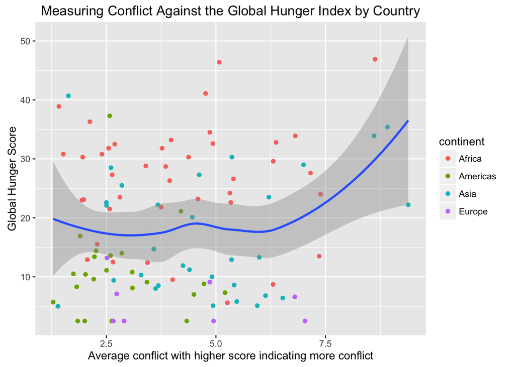

```r
############# Ggplot viz of Conflict against Hunger Score #######################
ggplot(na.omit(df), aes(Average_Conflict, Hunger_Score)) +
  geom_point(aes(color=continent)) +
  geom_smooth() +
  xlab ('Average conflict with higher score indicating more conflict') +
  ylab ('Global Hunger Score') +
  ggtitle ('Measuring Conflict Against the Global Hunger Index by Country')
```

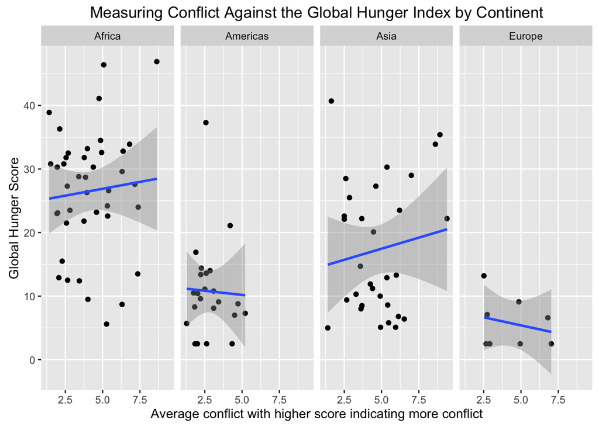

```r
############# Ggplot viz above subset / facet wrapped by continent #######################
ggplot(na.omit(df), aes(Average_Conflict, Hunger_Score)) +
  geom_point() +
  geom_smooth(method="lm") +
  facet_grid(. ~ continent) +
  xlab ('Average conflict with higher score indicating more conflict') +
  ylab ('Global Hunger Score') +
  ggtitle ('Measuring Conflict Against the Global Hunger Index by Continent')
```

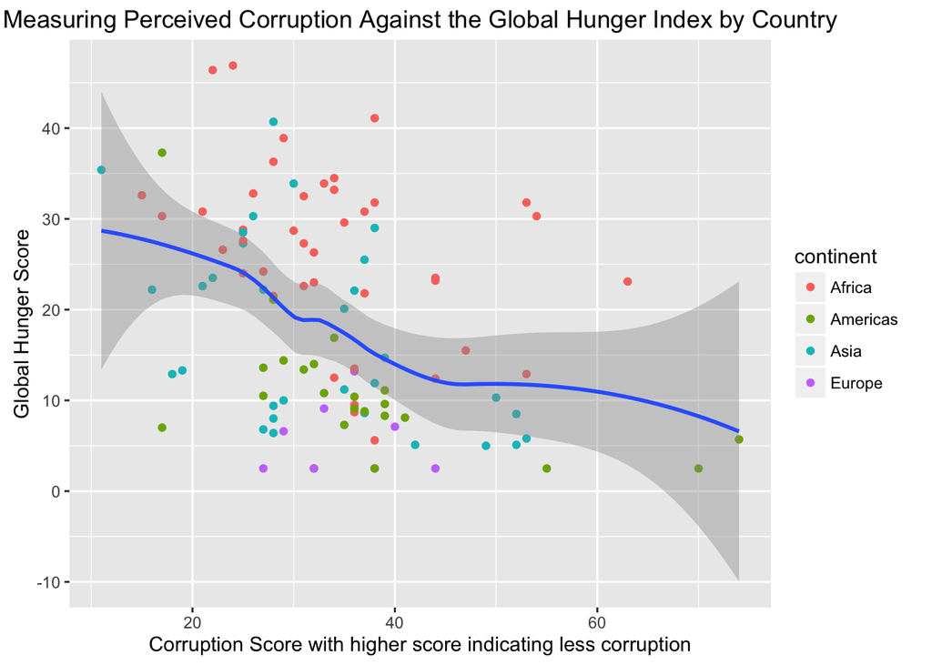

```r
############# Ggplot viz of Corruption against Hunger Score #######################
ggplot(na.omit(df), aes(Corruption_Score, Hunger_Score)) +
  geom_point(aes(color=continent)) +
  geom_smooth() +
  xlab ('Corruption Score with higher score indicating less corruption') +
  ylab ('Global Hunger Score') +
  ggtitle ('Measuring Perceived Corruption Against the Global Hunger Index by Country')
```

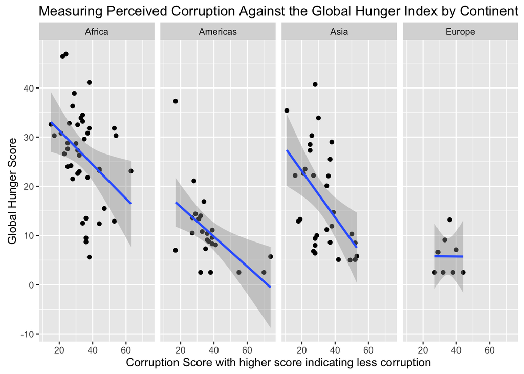

```r
############# Ggplot viz above subset / facet wrapped by continent #######################
ggplot(na.omit(df), aes(Corruption_Score, Hunger_Score)) +
  geom_point() +
  geom_smooth(method="lm") +
  facet_grid(. ~ continent) +
  xlab ('Corruption Score with higher score indicating less corruption') +
  ylab ('Global Hunger Score') +
  ggtitle ('Measuring Perceived Corruption Against the Global Hunger Index by Continent')
```

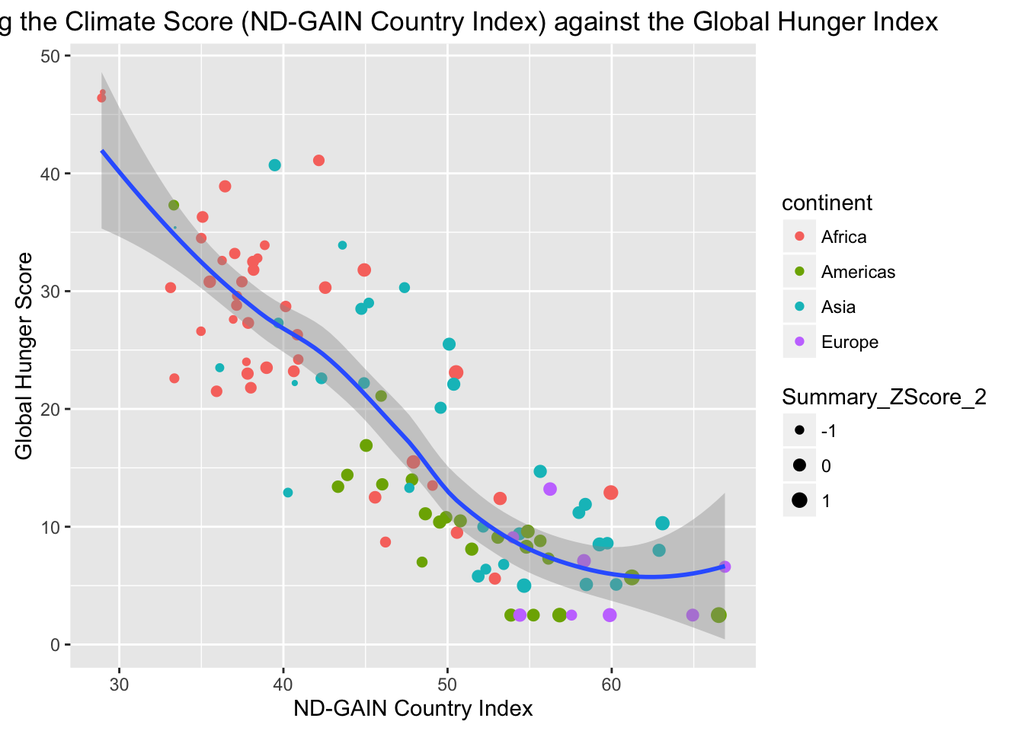

```r
############# Ggplot viz of Climate against Hunger Score #######################
climate_plot <- ggplot(na.omit(df), aes(Climate_NominalScore, Hunger_Score))
climate_plot + geom_point(aes(color=continent, size=Summary_ZScore_2)) + labs(title="Measuring the Climate Score (ND-GAIN Country Index) against the Global Hunger Index", x="ND-GAIN Country Index", y="Global Hunger Score") + geom_smooth() + scale_size(range = c(0, 3))
```

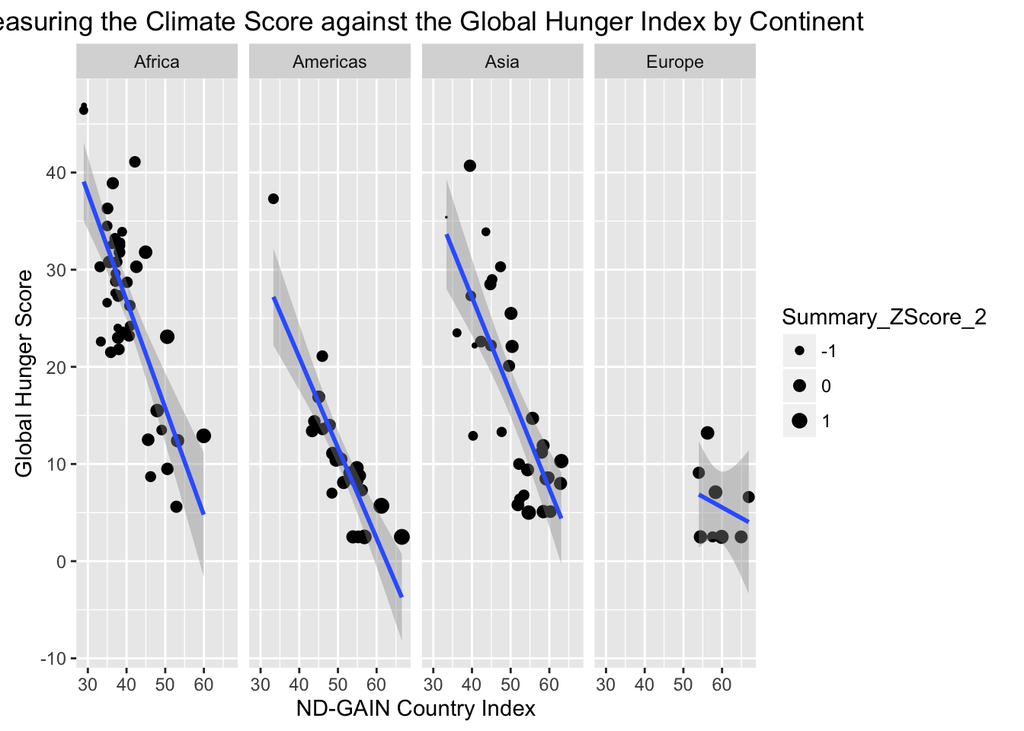

```r
############# Ggplot viz of above facet wrapped by continent #######################
climate_plot + geom_point(aes(size=Summary_ZScore_2)) + geom_smooth(method="lm") + facet_grid(~continent) + labs(title="Measuring the Climate Score against the Global Hunger Index by Continent", x="ND-GAIN Country Index", y="Global Hunger Score") + scale_size(range = c(0, 3))
```

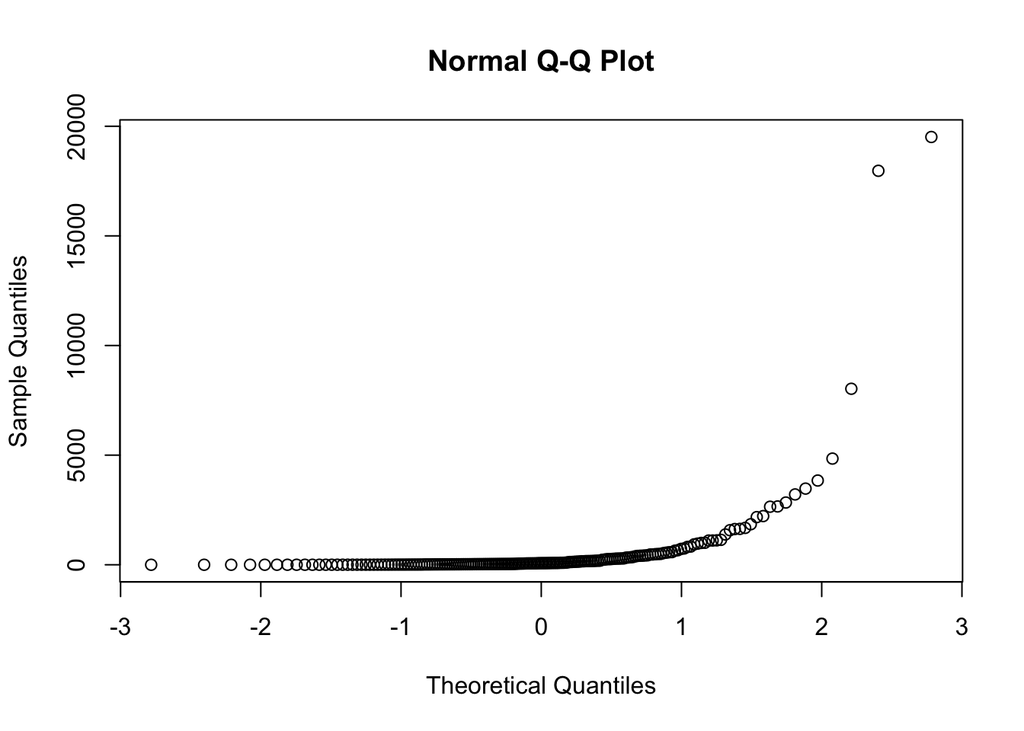

```r
######################### QQ Plot GDP #########################
qqnorm(df$GDP)  #very non-normal
```

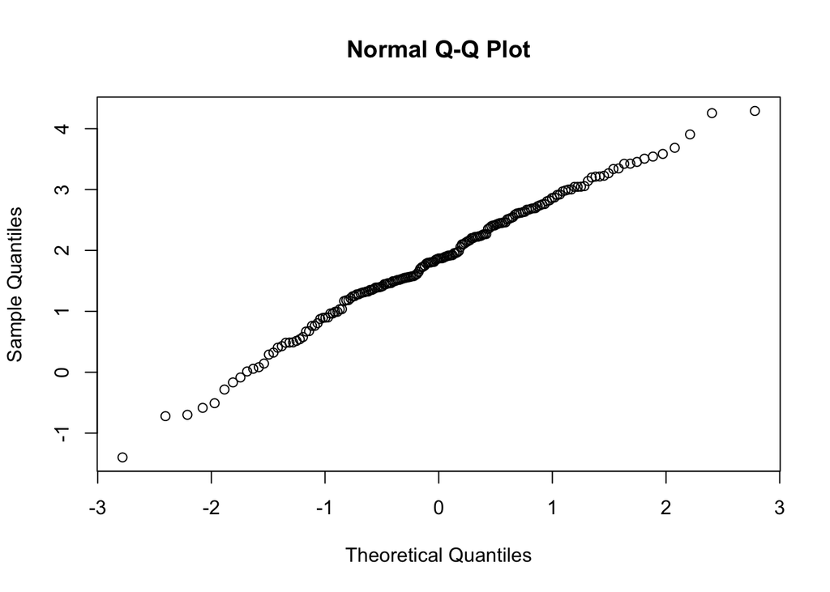

```r
qqnorm(log10(df$GDP)) #the log10 transformation aids in making the distribution more normal
```

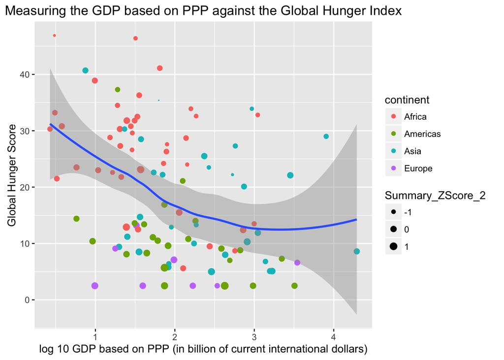

```r
############# Ggplot viz of GDP against Hunger Score #######################
gdp_plot <- ggplot(na.omit(df), aes(log10(GDP), Hunger_Score))
gdp_plot + geom_point(aes(color=continent, size=Summary_ZScore_2)) + labs(title="Measuring the GDP based on PPP against the Global Hunger Index", x="log 10 GDP based on PPP (in billion of current international dollars)", y="Global Hunger Score") + geom_smooth() + scale_size(range = c(0, 3))
```

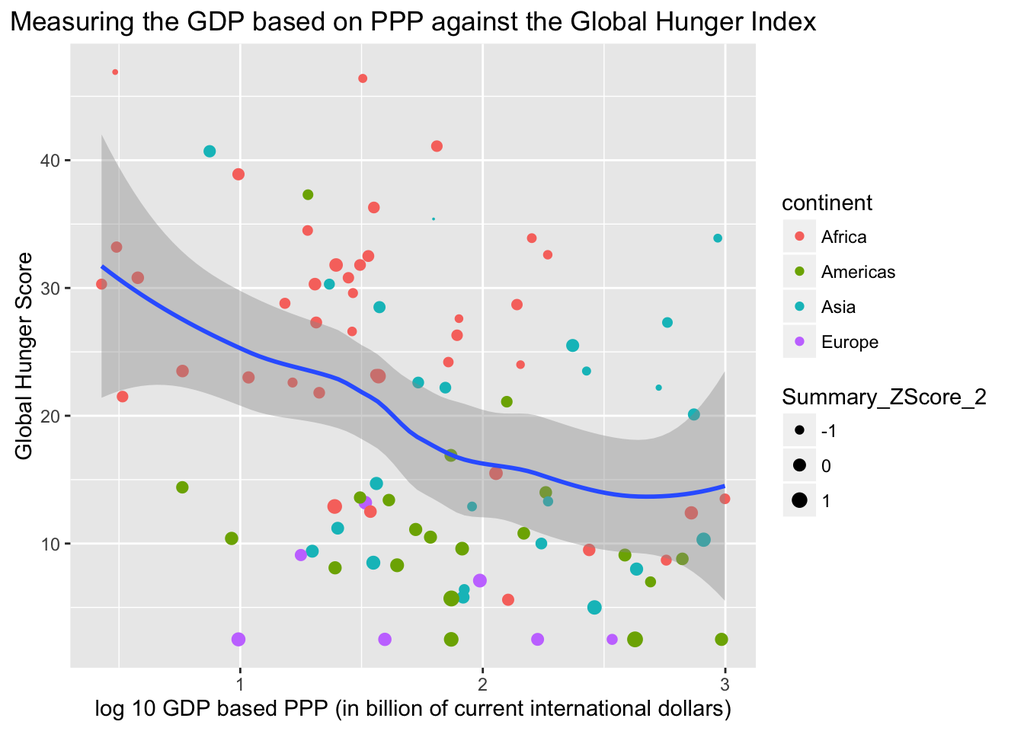

```r
############# Ggplot viz of GDP against Hunger Score (zoom in) #########################
df_2 <- df %>% filter(GDP<1000)
gdp_plot <- ggplot(na.omit(df_2), aes(log10(GDP), Hunger_Score))
gdp_plot + geom_point(aes(color=continent, size=Summary_ZScore_2)) + labs(title="Measuring the GDP based on PPP against the Global Hunger Index", x="log 10 GDP based PPP (in billion of current international dollars)", y="Global Hunger Score") + geom_smooth() + scale_size(range = c(0, 3))
```

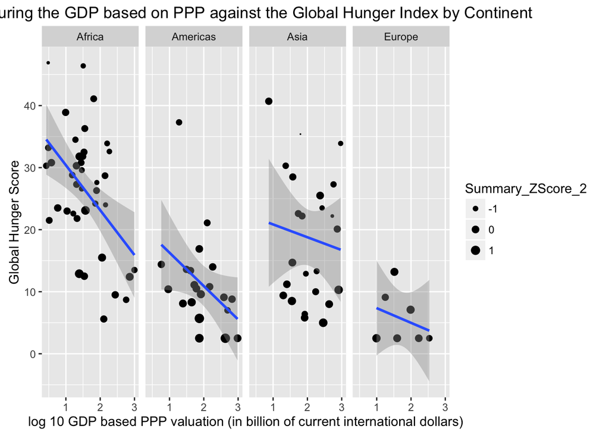

```r
############# Ggplot viz of above facet wrapped by continent #######################
gdp_plot + geom_point(aes(size=Summary_ZScore_2)) + geom_smooth(method="lm") + facet_grid(~continent) + labs(title="Measuring the GDP based on PPP against the Global Hunger Index by Continent", x="log 10 GDP based PPP valuation (in billion of current international dollars)", y="Global Hunger Score") + scale_size(range = c(0, 3))
```

Conflict Against the Global Hunger: Interestingly the relationship changes by continent. For Africa and Asia, as average conflict increases, the global hunger index increases (meaning more hunger). But for the Americas and Europe, the inverse relationship holds; as average conflict increases, the hunger decreases.

Climate Score Against Global Hunger: As the ND-GAIN index increases (increase in capacity to deal with potential climate risk), the global hunger decreases. We see this in both the overall plot and the plot broken down by continent.

GDP Against Global Hunger: First we note that GDP is very non-normally distributed so we use a log10 transformation. There is a relationship between hunger decreasing as GDP increases. We see this in both the overall plot and the plot broken down by continent.

# Exploring the Relationship Between the 3 Cs and Hunger Score

Initally we were interested in looking at the relationship between these 3Cs and the hunger score. As a reminder, the hunger score is the 2015 Global Hunger Index where 0 is the best score (no hunger) and 100 the worst. We preformed both graphical and regression analyses to investigate this association.

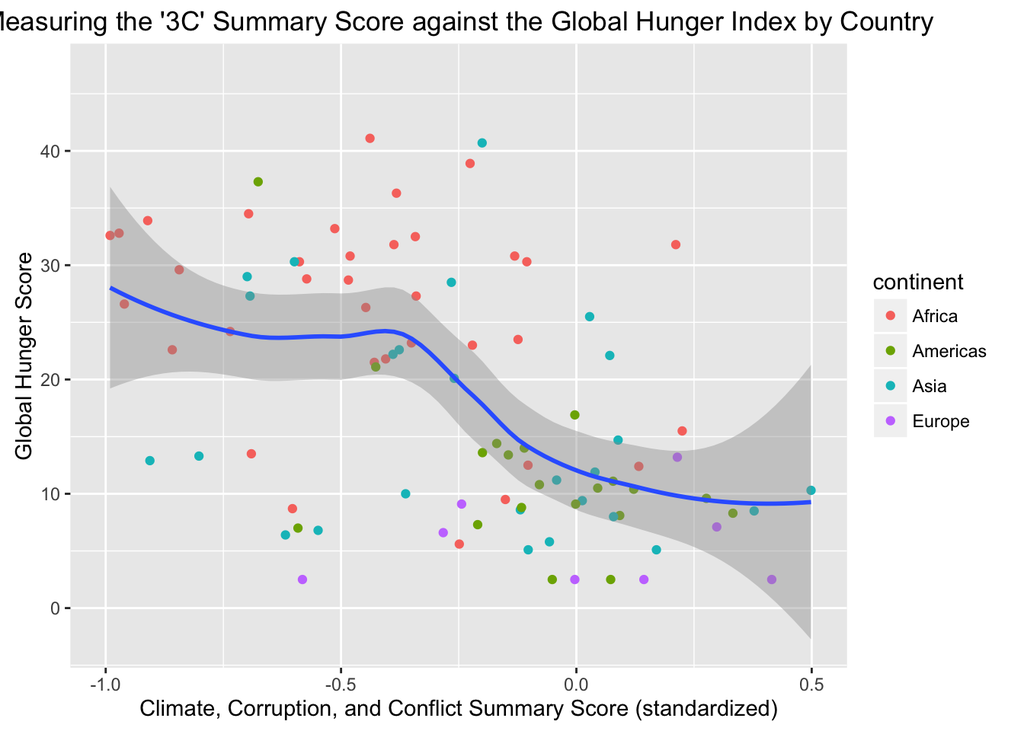

```r
###################################################
### Plotting summary score against Hunger Score####
###################################################

# Visualizations of 3C's against Hunger Score
hunger_summary <- ggplot(na.omit(df), aes(Summary_ZScore_2, Hunger_Score))
hunger_summary + geom_point(aes(color=continent)) + geom_smooth() + labs(title="Measuring the '3C' Summary Score against the Global Hunger Index by Country", x="Climate, Corruption, and Conflict Summary Score (standardized)", y="Global Hunger Score") + xlim(-1.0, 0.5)
```

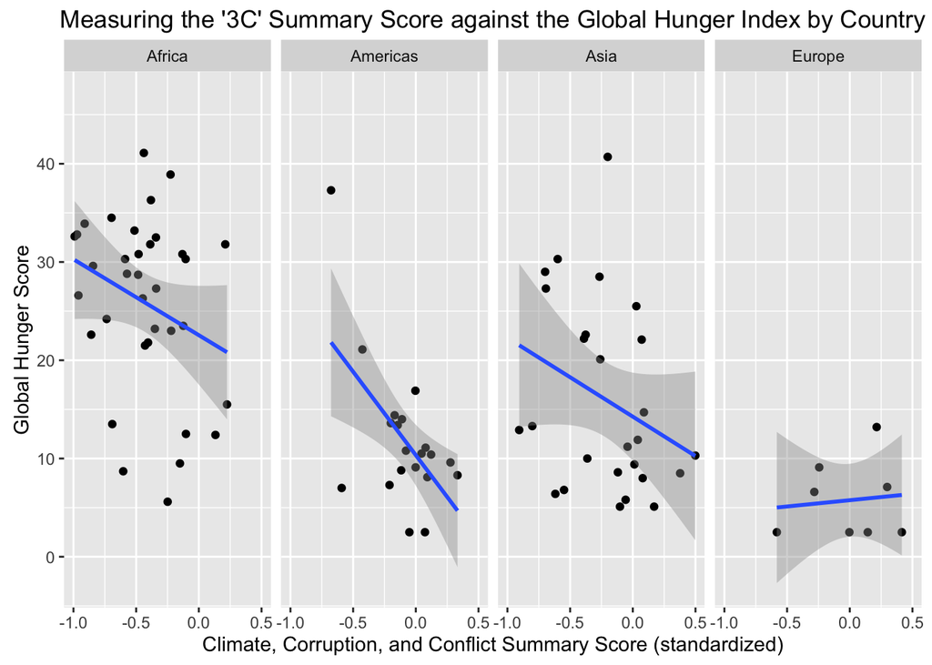

```r
# Subset visualizations by continent
hunger_summary + geom_point() + geom_smooth(method="lm") + facet_grid(~continent) + labs(title="Measuring the '3C' Summary Score against the Global Hunger Index by Country", x="Climate, Corruption, and Conflict Summary Score (standardized)", y="Global Hunger Score") + xlim(-1.0, 0.5)
```

```r
#####################################################
### Regressing summary score against Hunger Score ###
#####################################################

# Simple regression
mod1 <-lm(Hunger_Score~Summary_ZScore_2,data=na.omit(df))
summary(mod1)
```

```
##
## Call:
## lm(formula = Hunger_Score ~ Summary_ZScore_2, data = na.omit(df))
##
## Residuals:
##     Min      1Q  Median      3Q     Max
## -20.138  -6.078  -1.000   6.383  23.069
##
## Coefficients:
##                  Estimate Std. Error t value Pr(>|t|)
## (Intercept)        15.005      1.053  14.249  < 2e-16 ***
## Summary_ZScore_2  -13.115      1.807  -7.259 8.22e-11 ***
## ---
## Signif. codes:  0 '***' 0.001 '**' 0.01 '*' 0.05 '.' 0.1 ' ' 1
##
## Residual standard error: 9.423 on 101 degrees of freedom
## Multiple R-squared:  0.3429, Adjusted R-squared:  0.3364
## F-statistic:  52.7 on 1 and 101 DF,  p-value: 8.222e-11
```

```r
# Regression subset by continent
library(plyr)
# Break up df by continent, then fit the specified model to each piece and return a list
models <- dlply(na.omit(df), "continent", function(df)
  lm(Hunger_Score~Summary_ZScore_2, data = na.omit(df)))
# Apply coef to each model and return a data frame
ldply(models, coef)
```

```
##   continent (Intercept) Summary_ZScore_2
## 1    Africa   22.158523        -9.477450
## 2  Americas   11.252326        -9.961125
## 3      Asia   13.886782       -10.016213
## 4    Europe    5.756528         1.278295
```

```r
# Print the summary of each model
l_ply(models, summary, .print = TRUE)
```

```
##
## Call:
## lm(formula = Hunger_Score ~ Summary_ZScore_2, data = na.omit(df))
##
## Residuals:
##     Min      1Q  Median      3Q     Max
## -19.175  -4.727   1.052   6.177  14.786
##
## Coefficients:
##                  Estimate Std. Error t value Pr(>|t|)
## (Intercept)        22.159      1.931  11.476 4.51e-14 ***
## Summary_ZScore_2   -9.477      2.979  -3.182  0.00287 **
## ---
## Signif. codes:  0 '***' 0.001 '**' 0.01 '*' 0.05 '.' 0.1 ' ' 1
##
## Residual standard error: 8.708 on 39 degrees of freedom
## Multiple R-squared:  0.2061, Adjusted R-squared:  0.1857
## F-statistic: 10.12 on 1 and 39 DF,  p-value: 0.002872
##
##
## Call:
## lm(formula = Hunger_Score ~ Summary_ZScore_2, data = na.omit(df))
##
## Residuals:
##      Min       1Q   Median       3Q      Max
## -10.1445  -2.4055   0.3602   1.5536  19.3129
##
## Coefficients:
##                  Estimate Std. Error t value Pr(>|t|)
## (Intercept)        11.252      1.300   8.657 2.27e-08 ***
## Summary_ZScore_2   -9.961      2.980  -3.342  0.00309 **
## ---
## Signif. codes:  0 '***' 0.001 '**' 0.01 '*' 0.05 '.' 0.1 ' ' 1
##
## Residual standard error: 6.193 on 21 degrees of freedom
## Multiple R-squared:  0.3472, Adjusted R-squared:  0.3162
## F-statistic: 11.17 on 1 and 21 DF,  p-value: 0.003088
##
##
## Call:
```

[output cut: 20 more lines]

```
##
## Residuals:
##     Min      1Q  Median      3Q     Max
## -3.7871 -3.2992 -0.7752  1.8176  7.1693
##
## Coefficients:
##                  Estimate Std. Error t value Pr(>|t|)
## (Intercept)         5.757      1.515   3.799  0.00898 **
## Summary_ZScore_2    1.278      4.774   0.268  0.79786
## ---
## Signif. codes:  0 '***' 0.001 '**' 0.01 '*' 0.05 '.' 0.1 ' ' 1
##
## Residual standard error: 4.286 on 6 degrees of freedom
## Multiple R-squared:  0.01181,    Adjusted R-squared:  -0.1529
## F-statistic: 0.07169 on 1 and 6 DF,  p-value: 0.7979
```